# Farquahar Model

Hao-Ran Wu ( haoranwu @ zju.edu.cn )

2022-09-16

In this section we are concerned about how to calculate ecosystem production based on Farquahar model.

## Code Example(s)

An <- photo.farquhar(ci, Vmax, Jmax, Q10, Rd = Rd)

```r
# Ecosystem Production based on Farquahar Model
# *****************************************************************
#
# Calculate ecosystem production based on Farquahar Model (Farquahar
# and Menten, 1980)
#
# ********************************
# List of variables and units for this example
#
# 'ci'          intercellular CO2 concentration (µmol mol−1)
# 'Vmax'        maximum activity of Rubisco (µmol m−2 s−1)
# 'Jmax'        electron transport rate (µmol m−2 s−1)
# 'Q10'         Q10 value of leaf respiration modeled with leaf temperature
# 'Rd'          respiration rate (μmol m-2 s-1)
#
# Calculated variables in the program
# 'An'          net leaf CO2 assimilation rate (μmol m-2 s-1).
#
# ********************************
# Step 1: import package
require(bproce)

# Step 2: choose parameters
ci   <- seq(1e4, 1e5, 1e3)
Vmax <- 20
Jmax <- 200
Q10  <- 3.18
Rd   <- 0

# Step 3: run the model
An   <- photo.farquhar(ci, Vmax, Jmax, Q10, Rd = Rd)

# Step 4: present and visualize the result
print(data.frame(ci, An), digits = 3)
       # column 1: intercellular CO2 concentration
       # column 2: predicted net leaf CO2 assimilation rate

plot(
    ci, An, type="l",
    xlab = expression("Intercellular "*CO[2]*" concentration"),
    ylab = expression("Net leaf "*CO[2]*" assimilation rate"),
    main = "Photosynthesis Rate Estimated by Farquahar Model"
)
```

## Explanation

**Step1:** Load the package `bproce` through the `require()` function.

```r
require(bproce)
```

**Step2:** Choose model parameters.

- `ci`: Intercellular CO<sub>2</sub> concentration ($c_i$, µmol mol<sup>−1</sup>). The provided example calculates net leaf CO<sub>2</sub> assimilation rate ($A_n$, µmol m<sup>−2</sup> s<sup>−1</sup>) when $c_i$ changes from 10<sup>4</sup> to 10<sup>5</sup> µmol m<sup>−2</sup> s<sup>−1</sup>.
- `Vmax`: Maximum activity of Rubisco (µmol m<sup>−2</sup> s<sup>−1</sup>). The provided example uses 20 µmol m<sup>−2</sup> s<sup>−1</sup>.
- `Jmax`: Electron transport rate (µmol m<sup>−2</sup>s<sup>−1</sup>). The provided example uses 200 µmol m<sup>−2</sup> s<sup>−1</sup>.
- `Q10`: Q10 value of leaf respiration modeled with leaf temperature. The provided example uses 3.18.
- `Rd`: Respiration rate (μmol m<sup>−2</sup> s<sup>−1</sup>). The provided example assumes no respiration.

```r
ci   <- seq(1e4, 1e5, 1e3)
Vmax <- 20
Jmax <- 200
Q10  <- 3.18
Rd   <- 0
```

**Step 3:** Run the model. The Farquhar model expresses the relationship between $A_n$ and three rates:

$$A_n = \min(A_c, A_j, A_p),\quad (1)$$
where $A_c$, $A_j$, and $A_p$ are the photosynthesis rate for Rubisco-limited, RuBP-limited, and product-limited assimilations, respectively. Firstly, the photosynthesis rate $A_c$ can be calculated as:

$$A_c=\frac{V_{max}·(c_i-\Gamma^*)}{c_i+K_c·(1+\frac{o_i}{K_o})}, \quad
(2)$$

$$\Gamma^*=\frac{0.5·o_i}{2600·0.57^{Q_{10}}},\quad(3)$$

$$K_c=30·2.1^{Q_{10}},\quad (4)$$

$$K_o=30000·1.2^{Q_{10}},\quad(5)$$

where $V_{max}$ is the maximum activity of Rubisco (µmol m<sup>−2</sup> s<sup>−1</sup>), $c_i$ is the intercellular CO<sub>2</sub> concentration (µmol mol<sup>−1</sup>), $Γ^∗$ is the CO<sub>2</sub> compensation point in the absence of day respiration ($R_d$), $K_c$ is the Michaelis-Menten constant of Rubisco for CO<sub>2</sub>, $o_i$ is the oxygen (O<sub>2</sub>) concentration in the atmosphere (209 mol mol<sup>−1</sup>), $K_o$ is the Michaelis-Menten constant of Rubisco for O<sub>2</sub>, and $Q_{10}$ is the leaf respiration and can be modeled with leaf temperature.

Secondly, the RuBP-limited photosynthesis rate $A_j$ is calculated as:

$$A_j=\frac{J_{max}·(c_i-\Gamma^*)}{4·c_i+8·\Gamma^*},\quad (6)$$
where $J_{max}$ is the electron transport rate (µmol m<sup>−2</sup> s<sup>−1</sup>) and varies with absorbed photosynthetically active radiation.

Finally, the product-limited photosynthesis rate is calculated as:

$$A_p=3·T_p,\quad (7)$$
where $T_p$ (µmol m<sup>−2</sup>) is the triose phosphate utilization rate. This rarely limits the rate of photosynthesis under physiological conditions, hence the default value of $T_p$ being infinitive in the function `photo.farquhar()`.

```r
An   <- photo.farquhar(ci, Vmax, Jmax, Q10, Rd = Rd)

print(head(data.frame(ci, An)), digits = 3)
```

```
##      ci     An
## 1 10000 -11.20
## 2 11000 -10.09
## 3 12000  -9.03
## 4 13000  -8.00
## 5 14000  -7.00
## 6 15000  -6.04
```

```r
       # column 1: intercellular CO2 concentration
       # column 2: predicted net leaf CO2 assimilation rate
```

| Argument | Data Type | Meaning | Symbol |
| --- | --- | --- | --- |
| `ci` | vector | intercellular CO<sub>2</sub> concentration (µmol mol<sup>−1</sup>) | $c_i$ |
| `Vmax` | scalar | maximum activity of Rubisco (µmol m<sup>−2</sup> s<sup>−1</sup>) | $V_{max}$ |
| `Jmax` | scalar | electron transport rate (µmol m<sup>−2</sup> s<sup>−1</sup>) | $J_{max}$ |
| `Q10` | scalar | Q10 value of leaf respiration | $Q_{10}$ |
| `Tp` | scalar | triose phosphate utilization rate (µmol m<sup>−2</sup>). Default infinitive | $T_p$ |
| `oi` | scalar | oxygen (O<sub>2</sub>) concentration in the atmosphere. Default 209 mol mol<sup>-1</sup> | $o_i$ |
| `Rd` | scalar | respiration rate (μmol m<sup>-2</sup> s<sup>-1</sup>) | $R_d$ |

**Step4:** Visualize the result. Create a line plot of $A_n$ against $c_i$ through the function `plot()`:

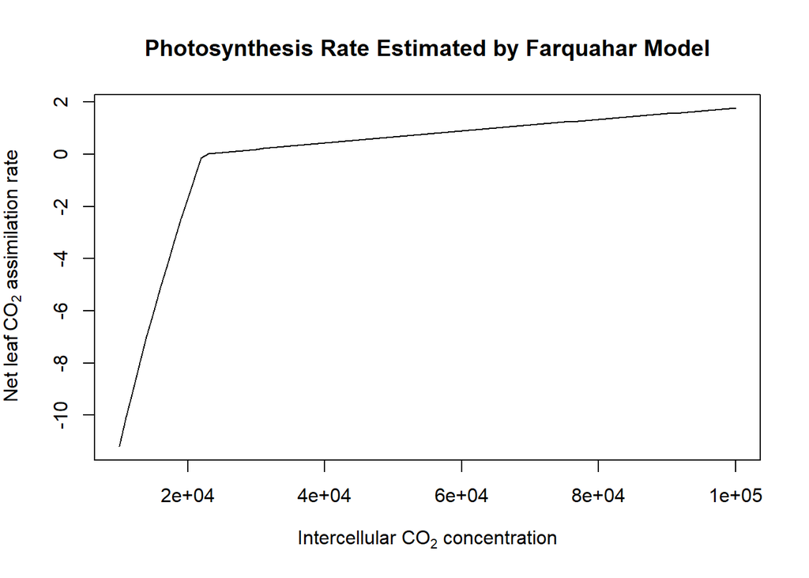

```r
plot(
    ci, An, type="l",
    xlab = expression("Intercellular "*CO[2]*" concentration"),
    ylab = expression("Net leaf "*CO[2]*" assimilation rate"),
    main = "Photosynthesis Rate Estimated by Farquahar Model"
)
```

## Reference

Farquhar, G. D., von Caemmerer, S. V., and Berry, J. A. (1980). A biochemical model of photosynthetic CO2 assimilation in leaves of C3 species. Planta, 149(1), 78–90.